# Reproducible Results - Impact of Weather Related Events in terms of Harm to Public Health and Economic Impact For the Period of 1950 - November 2011

richdata

Tuesday, November 11, 2014

## Synopsis

In this report I will analyze the human and economic impact of weather related events the United States between the years 1950 and 2011. The hypothesis is that storms and other severe weather events can cause both public health and economic problems for communities and municipalities. Reviewing NOASS’s data for the years 1950 and 2011, I found that, tornados had a significantly larger impact on human life than any other event but surprisingly, it didn’t translate to significant economic impact where floods topped the list of economic impact caused by weather events.

This report will summarize the results of exploring the NOAA Storm Database and specifically answer two questions: 1. Across the United States, which types of events (as indicated in the EVTYPE variable) are most harmful with respect to population health? 2. Across the United States, which types of events have the greatest economic consequences?

## Data Processing

This project involves exploring the U.S. National Oceanic and Atmospheric Administration’s (NOAA) storm database. This database tracks characteristics of major storms and weather events in the United States, including when and where they occur, as well as estimates of any fatalities, injuries, and property damage.

### *Initialization*

To begin, some initial housekeeping is required to ensure this is a reproducible research project by installing/loading the needed datasets, documenting the environment, downloading the data and reading the file. It should be noted that there was a considerable exploration effort outside of this document to gain some insights into the data. For brevity, those efforts are not included here.

```r
#
#install and load the ggplot2 package

install.packages ("ggplot2", repos="http://cran.rstudio.com/", quiet=TRUE)
library (ggplot2)
library (grid)  #needed for theme panel margin units
library (plyr)
#
# Document the Software Environment to make it easily reproduced
#
sessionInfo ()
```

[output not shown]

If the directory or files already exist, then don’t create them or download the data again as the download could be a timely process because the file is quite large.

```r
setwd ("~/My Personal Stuff/coursera/Reproducible Research/Project2")

# if the data directory doesn't exist create it

if (!file.exists("Data")) {
        dir.create("Data")
        }

#if the data file doesn't exist, the download it

if(!file.exists("Data/repdata-data-StormData.csv.bz2")) {
        fileURL <- "http://d396qusza40orc.cloudfront.net/repdata%2Fdata%2FStormData.csv.bz2"
        download.file(fileURL, destfile = "./Data/repdata-data-StormData.csv.bz2")
        fileNAME <- "./Data/repdata-data-StormData.csv.bz2"
        }

stormdata <- read.csv(bzfile("./data/repdata-data-StormData.csv.bz2"))

#strip out only data we're interested in
stormdata <- stormdata [, c("EVTYPE","FATALITIES","INJURIES","PROPDMG","PROPDMGEXP","CROPDMG","CROPDMGEXP")]
```

### *Cleaning the data & transformations*

To speed things up, the original dataset will be stripped of unnecessary columns and any rows that contain zero values in all relevant study variables (i.e. Fatalities, Injuries, Property Damage and Crop Damage). This reduction removed 30 variables and over 65,000 observations.

Additionally, the CODEBOOK associated with this dataset, https://d396qusza40orc.cloudfront.net/repdata%2Fpeer2_doc%2Fpd01016005curr.pdf, suggests there are 48 differientiating events. However, initial exploration of the EVTYPES in the dataset indicated there were 898 different coded event types! Some cleaning of obvious typos and significant consolidation of the data was required.

To nicely handle coded events that didn’t fit easily into a pre-established group, things like Drowning and Marine Mishap were placed into the OTHER category.

After the groupings were established, the damage classifications needed to be cleaned up a bit. The Codebook said damage amounts should have alphabetical characters to signify magnitude such as “K” for thousands, “M” for millions, and “B” for billions. However, upon inspection of the data, there were characters (i.e. ?, - or +) and numbers. Since the number of records with the characters were small and the associated amounts were small, it was decided to remove those observations from the dataset. However, the number of records with numeric indicators was significant. An inspection of several remarks variables, it was determined that the numeric indicators were an order of magnitude and were kept in the dataset under that assumption and the K, M and B indicators were converted to 3,6 and 9 respectively to remain consistent with the previous assumption.

```r
# remove any rows that don't have any fatalities, injuries or damage
stormdata <- stormdata[apply(stormdata[c(2,3,4,6)],1,function(z) any(z!=0)),]

#make sure all datas are all upper case to normalize categories
#for example Wintry mix, Wintry Mix and WINTRY MIX
stormdata$EVTYPE <- as.factor (toupper (stormdata$EVTYPE))

#
#There are a bunch of Event Types that are obvious typos and variations
#There are also far many events than the 48 called out in the Cookbook Table 2.1.1
# located here: https://d396qusza40orc.cloudfront.net/repdata%2Fpeer2_doc%2Fpd01016005curr.pdf

#Let's first consolidate and clean up a bit.

# Create an AVALANCHE Group (mainly fix spelling error)
#
stormdata[grep("AVALANCE",stormdata$EVTYPE),]$EVTYPE <- "AVALANCHE"
#
# Create a BLIZZARD Group
#
stormdata[grep("BLIZZARD",stormdata$EVTYPE),]$EVTYPE <- "BLIZZARD"
#
# Create COASTAL FLOOD Group
#
#Put Coastal Surge into Storm Surge/Tide group instead of Coastal Flooding
stormdata[grep("COASTAL SURGE",stormdata$EVTYPE),]$EVTYPE <- "STORM SURGE/TIDE"
stormdata[grep("COASTAL|BEACH EROSION|CSTL FLOOD|TIDAL FLOODING|ASTRONOMICAL HIGH TIDE",stormdata$EVTYPE),]$EVTYPE <- "COASTAL FLOOD"
#
# Create a COLD Groups
#
#put COLD AIR TORNADO in the TORNADO GROUP
stormdata[grep("COLD AIR TORNADO",stormdata$EVTYPE),]$EVTYPE <- "TORNADO"
stormdata[grep("^COLD|HYPOTHERMIA|LOW TEMPERATURE",stormdata$EVTYPE),]$EVTYPE  <-"COLD/WIND CHILL"
stormdata[grep(" COLD|WINDCHILL|EXTREME WIND CHILL",stormdata$EVTYPE),]$EVTYPE <- "EXTREME COLD/WIND CHILL"
#
# combine the FOG entries into DENSE FOG, except FREEZING FOG
stormdata[grep("DENSE FOG|^FOG",stormdata$EVTYPE),]$EVTYPE <- "DENSE FOG"
#
# combine the DROUGHT entries into one
stormdata[grep("DROUGHT",stormdata$EVTYPE),]$EVTYPE <- "DROUGHT"
# Create DUST Events: Devil & Storm
#
stormdata[grep("DUST DEVIL",stormdata$EVTYPE),]$EVTYPE <- "DUST DEVIL"
stormdata[grep("DUST STORM|BLOWING DUST",stormdata$EVTYPE),]$EVTYPE <- "DUST STORM"
#
# Group HEAT Events
#
stormdata[grep("HEAT WAVE|RECORD HEAT|RECORD/EXCESSIVE HEAT|EXTREME HEAT",stormdata$EVTYPE),]$EVTYPE <- "EXCESSIVE HEAT"
stormdata[grep("HYPERTHERMIA|WARM",stormdata$EVTYPE),]$EVTYPE="HEAT"
#
# combine the FLOOD Groups(FLASH-COMBINE FLash type events, FLOOD-All Other)
# NOTE - Need to keep LAKESHORE FLOOD separate so careful selection will be needed

stormdata[grep("FLASH|DAM BREAK|RAPIDLY RISING WATER",stormdata$EVTYPE),]$EVTYPE <- "FLASH FLOOD"
stormdata[grep("FLOODING|HIGH WATER|ICE JAM|URBAN",stormdata$EVTYPE),]$EVTYPE <- "FLOOD"
stormdata[grep("RIVER FL|URBAN FL|RURAL FL|STREAM FL",stormdata$EVTYPE),]$EVTYPE<- "FLOOD"
stormdata[grep("FLOODS|MAJOR FL|& FLOOD|AND FLOOD|FLOOD &",stormdata$EVTYPE),]$EVTYPE <- "FLOOD"
stormdata[grep("FLOOD/|/ FLOOD",stormdata$EVTYPE),]$EVTYPE <- "FLOOD"
#
# Create FREEZE Group
#
stormdata[grep("FREEZE|FROST",stormdata$EVTYPE),]$EVTYPE <- "FROST/FREEZE"
#
# Create HAIL Group
#
stormdata[grep("^HAIL|SMALL HAIL|/HAIL",stormdata$EVTYPE),]$EVTYPE <- "HAIL"
#
# Create a HEAVY RAIN Group (INCLUDE HEAVY PERCIP BECAUSE DATA COMMENT DISCUSSES RAINFALL)
#
stormdata[grep("FREEZING RAIN",stormdata$EVTYPE),]$EVTYPE <- "WINTER WEATHER"
stormdata[grep("HEAVY RAIN|HEAVY SHOWER|HVY RAIN",stormdata$EVTYPE),]$EVTYPE <- "HEAVY RAIN"
stormdata[grep("WETNESS|COOL AND WET|HEAVY PRECIPITATION",stormdata$EVTYPE),]$EVTYPE<-"HEAVY RAIN"
stormdata[grep("RECORD RAIN|RAINSTORM|^UNSEASONAL RAIN",stormdata$EVTYPE),]$EVTYPE <- "HEAVY RAIN"
stormdata[grep("EXCESSIVE RAIN|RAIN/|^RAIN$",stormdata$EVTYPE),]$EVTYPE <- "HEAVY RAIN"
stormdata[grep("TORRENTIAL RAIN|WIND/RAIN",stormdata$EVTYPE),]$EVTYPE <- "HEAVY RAIN"
#
# Create a HEAVY SNOW Group
#
stormdata[grep("HEAVY SNOW|RECORD SNOW|EXCESSIVE SNOW",stormdata$EVTYPE),]$EVTYPE <- "HEAVY SNOW"
stormdata[grep("HEAVY LAKE SNOW|LATE SEASON",stormdata$EVTYPE),]$EVTYPE <- "HEAVY SNOW"
#
# Create a HIGH SURF Group (Put RIP CURRENTS/SURF into RIP CURRENTS FIRST)
#
stormdata[grep("RIP",stormdata$EVTYPE),]$EVTYPE="RIP CURRENT"
stormdata[grep("SURF|SWELLS|ROGUE WAVE|ROUGH SEA|HEAVY SEAS|HIGH SEAS|HIGH WAVE",stormdata$EVTYPE),]$EVTYPE<-"HIGH SURF"
#
# Create a HIGHWINDS
#
#raw data suggests this lone "HIGH" is high wind
stormdata[stormdata$EVTYPE == "HIGH",]$EVTYPE <- "HIGH WIND"
stormdata[grep("^HIGH WIND|HIGH  WINDS|STORM FORCE WIND",stormdata$EVTYPE),]$EVTYPE<-"HIGH WIND"
#
# Create a HURRICANE Group
#
stormdata[grep("HURRICANE|TYPHOON",stormdata$EVTYPE),]$EVTYPE <- "HURRICANE/TYPHOON"
#
# Create a ICE Group before snow because doing snow first would pull out ICE AND SNOW
# -- assumption is if ICE is listed first, it is more impactful.
#
#But first move non-ice storm events into Winter Weather & ICE FLOES to OTHER
stormdata[grep("BLACK ICE|ROAD",stormdata$EVTYPE),]$EVTYPE <- "WINTER WEATHER"
stormdata[grep("ICE FLOES",stormdata$EVTYPE),]$EVTYPE <- "OTHER"
stormdata[grep("^ICE|^ICY|GLAZE|ICE STORM",stormdata$EVTYPE),]$EVTYPE <- "ICE STORM"
#
# LAKE EFFECT SNOW
#
stormdata[grep("LAKE.*SNOW",stormdata$EVTYPE),]$EVTYPE<- "LAKE EFFECT SNOW"
#
# LAKESHORE FLOODING
#
stormdata[grep("LAKE FLOOD",stormdata$EVTYPE),]$EVTYPE<- "LAKESHORE FLOOD"
# Create LIGHTNING Group
#
stormdata[grep("LIGHTNING|LIGHTING|LIGNTNING",stormdata$EVTYPE),]$EVTYPE <- "LIGHTNING"
#
# Combine Marine TSTM and MARINE THUNDERSTORM EVENTS
#
stormdata[grep("MARINE TSTM",stormdata$EVTYPE),]$EVTYPE <- "MARINE THUNDERSTORM WIND"

#
# Create SLEET Group by putting SNOW/SLEET into WINTERWEATHER and leaving just SLEET
#
stormdata[grep("SNOW/SLEET",stormdata$EVTYPE),]$EVTYPE <- "WINTER WEATHER"
#
# Create SURGE/TIED Group by combining the two types of STORM SURGE
#
stormdata[grep("STORM SURGE|HIGH TIDE",stormdata$EVTYPE),]$EVTYPE <- "STORM SURGE/TIDE"
#
# Create a STRONG WINDS Group
stormdata[grep("^WIND|GUSTY WIND|SEVERE TURBULENCE",stormdata$EVTYPE),]$EVTYPE<-"STRONG WIND"
stormdata[grep("^STRONG WIND|^GRADIENT|NON.*TSTM|WIND DAM",stormdata$EVTYPE),]$EVTYPE<-"STRONG WIND"
#
# Create a THUNDERSTORM WIND Group
#
stormdata[grep("^THUNDER|^TSTM|BURST|TUNDERSTORM|THUNERSTORM|THUDER|THUNDEER",stormdata$EVTYPE),]$EVTYPE <- "THUNDERSTORM WIND"
stormdata[grep("^THUNDER|^SEVERE THUNDER",stormdata$EVTYPE),]$EVTYPE <- "THUNDERSTORM WIND"
stormdata[grep("TSTM WIND|GUSTNADO|WHIRLWIND",stormdata$EVTYPE),]$EVTYPE <- "THUNDERSTORM WIND"
#
# Create a TORNADO Group
#
stormdata[grep("TORNADO|TORNDAO|LANDSPOUT",stormdata$EVTYPE),]$EVTYPE <- "TORNADO"
#
# Consolidate all TROPICAL STORM
#
stormdata[grep("TROPICAL STORM",stormdata$EVTYPE),]$EVTYPE <- "TROPICAL STORM"
#
# Create a WATERSPOUT Group
#
stormdata[grep("^WATERSPOUT",stormdata$EVTYPE),]$EVTYPE <- "WATERSPOUT"
#
# Create a WILDFIRE Group
#
stormdata[grep("FIRE",stormdata$EVTYPE),]$EVTYPE <- "WILDFIRE"
#
#Create a WINTER STORM GROUP
# From CODEBOOK-A winter weather event which has more than one significant hazard
#  (i.e., heavy snow and blowing snow; snow and ice; snow and sleet; sleet and ice; or snow, sleet
# and ice)
#
stormdata[grep("WINTER STORM|BLOWING SNOW|HEAVY MIX",stormdata$EVTYPE),]$EVTYPE <- "WINTER STORM"
stormdata[grep("SNOW AND ICE|SNOW/",stormdata$EVTYPE),]$EVTYPE <- "WINTER STORM"
#
# Create WINTER WEATHER GROUP
stormdata[grep("MIXED PRECIP|^SNOW",stormdata$EVTYPE),]$EVTYPE <- "WINTER WEATHER"
#Carefully strip out Freezing to leave FREEZING FOG
stormdata[grep("^FREEZING [RDS]",stormdata$EVTYPE),]$EVTYPE <- "WINTER WEATHER"
stormdata[grep("^WINTER WEATHER|WINTRY|LIGHT SNOW",stormdata$EVTYPE),]$EVTYPE <- "WINTER WEATHER"
#
# Finally, create an OTHER group for things that don't fit nicely

stormdata[grep("\\?|APACHE|DROWNING|ACCIDENT|MISHAP|SLIDE|SLUMP",stormdata$EVTYPE),]$EVTYPE <- "OTHER"

#----------------------------------------------------------------------------------
# Clean up the property/crop Damage EXplanation (PROPDMGEXP & CROPDMGEXP)
# Drop everything that is not H/K/M/B because the code book says it should be characters
#stripout all rows that have 0 for prop & crop damage
#stormdata <- stormdata[apply(stormdata[,c(4,6)],1,function(z) any(z!=0)),]
#strip out any rows that have a + or ?
stormdata <- subset(stormdata, stormdata$PROPDMGEXP != "+" & stormdata$PROPDMGEXP !=
    "-" & stormdata$PROPDMGEXP != "?" & stormdata$CROPDMGEXP != "+" & stormdata$CROPDMGEXP != "-" & stormdata$CROPDMGEXP != "?" )

stormdata$PROPDMGEXP <- as.character(stormdata$PROPDMGEXP)
stormdata[grep("[hH]",stormdata$PROPDMGEXP),]$PROPDMGEXP <- 2
stormdata[grep("[kK]",stormdata$PROPDMGEXP),]$PROPDMGEXP <- 3
stormdata[grep("[mM]",stormdata$PROPDMGEXP),]$PROPDMGEXP <- 6
stormdata[grep("[bB]",stormdata$PROPDMGEXP),]$PROPDMGEXP <- 9

stormdata$CROPDMGEXP <- as.character(stormdata$CROPDMGEXP)
stormdata[grep("[kK]",stormdata$CROPDMGEXP),]$CROPDMGEXP <- 3
stormdata[grep("[mM]",stormdata$CROPDMGEXP),]$CROPDMGEXP <- 6
stormdata[grep("[bB]",stormdata$CROPDMGEXP),]$CROPDMGEXP <- 9
```

## Results

### *Fatalities & Injuries*

*1. Across the United States, which types of events (as indicated in the EVTYPE variable) are most harmful with respect to population health?*

The following table shows the weather events with the number of fatalities, injuries and total of fatalities and injuries. The table shows the top 10 events in descending ordered based on the Total number of harmful observations. Tornados are by far the most dangerous weather event to humans by a almost 10 times more harm than Thunderstorm winds.

```r
fatalities <- aggregate(FATALITIES~EVTYPE,data=stormdata,FUN=sum)
injuries   <- aggregate(INJURIES~EVTYPE,data=stormdata,FUN=sum)
bodilyharm <- cbind(fatalities[,1:2], injuries[,2])
colnames(bodilyharm)<- c("Event","Fatalities","Injuries")
bodilyharm$Total <- bodilyharm$Fatalities + bodilyharm$Injuries
Top10_PersonalHarm <- head(arrange(bodilyharm, Total, decreasing=TRUE),n=10)

Top10_PersonalHarm[, c("Event", "Total")]
```

```
##                Event Total
## 1            TORNADO 97043
## 2  THUNDERSTORM WIND 10178
## 3     EXCESSIVE HEAT  9304
## 4              FLOOD  7388
## 5          LIGHTNING  6049
## 6               HEAT  3097
## 7        FLASH FLOOD  2838
## 8          ICE STORM  2445
## 9          HIGH WIND  1762
## 10          WILDFIRE  1698
```

**Table 1** - Total number of fatalities and injuries

Next, looking at fatalities and injuries individually, tornados remain at the top of both types of weather events but that is where the commonality ends. Excessive Heat is the #2 event for fatalities and moves to #3 by injuries.

Rip currents and Extreme cold/wind chill are more fatal but do not show up on the top 10 of injuries suggesting those events are more like to have a fatal impact and extra caution should be exercised during those events. Likewise, ice storms and fires show up in the injuries list but they aren’t in the top 10 of fatalities.

```r
Top10_fatalities <- head(arrange(bodilyharm, Fatalities, decreasing=TRUE),n=10)
Top10_fatalities <- Top10_fatalities [,1:2]
colnames (Top10_fatalities) <- c("Event","Number")

Top10_injuries <- head(arrange(bodilyharm, Injuries, decreasing=TRUE),n=10)
Top10_injuries <- Top10_injuries [,c(1,3)]
colnames (Top10_injuries) <- c("Event","Number")

cbind (Top10_fatalities[,1:2], Top10_injuries[,1:2])
```

```
##                      Event Number             Event Number
## 1                  TORNADO   5636           TORNADO  91407
## 2           EXCESSIVE HEAT   2195 THUNDERSTORM WIND   9442
## 3              FLASH FLOOD   1036    EXCESSIVE HEAT   7109
## 4                     HEAT    978             FLOOD   6873
## 5                LIGHTNING    817         LIGHTNING   5232
## 6        THUNDERSTORM WIND    736         ICE STORM   2343
## 7              RIP CURRENT    577              HEAT   2119
## 8                    FLOOD    515       FLASH FLOOD   1802
## 9  EXTREME COLD/WIND CHILL    310          WILDFIRE   1608
## 10               HIGH WIND    291         HIGH WIND   1471
```

**Table 2** - Comparison of fatalities (left) and injuries (right) for the top 10 events

Figure 1 below visually shows the total harm to the public health for each of the top 10 event types for fatalities and injuries. In order to visually see the relative numbers for fatalities and injuries for each of the events, the y-axis is arbitrarily clipped at 15,000.

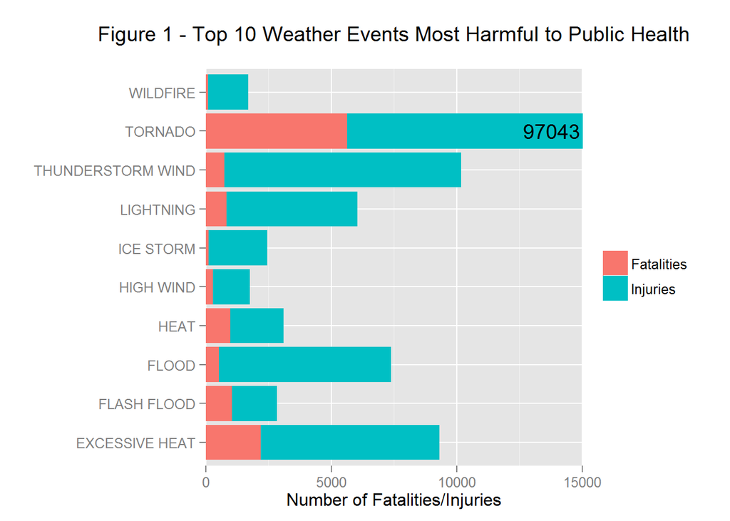

```r
#build the plot tables by combining both individual tables into a single table

Top10_fatalities$Type <- "Fatalities"
Top10_injuries$Type <- "Injuries"
bodilyharm <- rbind(Top10_fatalities,Top10_injuries)
bodilyharm$Type <- as.factor(bodilyharm$Type)
#
#add in the missing values for the fatalities/injuries
bodilyharm <- rbind(bodilyharm,c("EXTREME COLD/WIND CHILL",sum(stormdata[grep("EXTREME COLD/WIND CHILL",stormdata$EVTYPE),]$INJURIES),"Injuries"))
bodilyharm <- rbind(bodilyharm,c("RIP CURRENT",sum(stormdata[grep("RIP CURRENT",stormdata$EVTYPE),]$INJURIES),"Injuries"))
bodilyharm <- rbind(bodilyharm,c("ICE STORM",sum(stormdata[grep("ICE STORM",stormdata$EVTYPE),]$FATALITIES),"Fatalities"))
bodilyharm <- rbind(bodilyharm,c("WILDFIRE",sum(stormdata[grep("WILDFIRE",stormdata$EVTYPE),]$FATALITIES),"Fatalities"))
bodilyharm$Number <- as.numeric (bodilyharm$Number)
bodilyharm <- arrange (bodilyharm, bodilyharm$Type)
# Remove the two smallest to create a top 10
bodilyharm <-bodilyharm [-grep("EXTREME COLD",bodilyharm$Event),]
bodilyharm <-bodilyharm [-grep("RIP CURRENT",bodilyharm$Event),]

#
# Plot the events that were harmful to the population
#
 #create a line plot to show trend
g<- ggplot (bodilyharm, aes(x=Event, y=Number, fill=factor(Type)))
g + geom_bar(position="stack",stat="identity")+
        labs(title="Figure 1 - Top 10 Weather Events Most Harmful to Public Health\n",fill="",
        x="",y="Number of Fatalities/Injuries")+
        coord_flip (ylim = c(0,15000))+
        annotate("text", x = "TORNADO", y = 13800, label = as.character(sum(bodilyharm[grep("TORNADO",bodilyharm$Event),]$Number)))
```

### *Damages*

```r
#
#calculate total property and crop damage for each observation
stormdata$PROPAMT <- stormdata$PROPDMG* 10^as.numeric(stormdata$PROPDMGEXP)/(10^9)
stormdata$CROPAMT <- stormdata$CROPDMG*10^as.numeric(stormdata$CROPDMGEXP)/(10^9)
#group computed damage amounts by event types
propdmg <- aggregate(PROPAMT~EVTYPE,data=stormdata,FUN=sum)
cropdmg <- aggregate(CROPAMT~EVTYPE,data=stormdata,FUN=sum)
# determine the top 10 events of property damage
damage <- aggregate (PROPAMT~EVTYPE, data=stormdata, FUN=sum)
Top10_propdmg <- head(arrange(damage, PROPAMT, decreasing=TRUE),n=10)
Top10_propdmg$PROPAMT <- Top10_propdmg$PROPAMT
Top10_propdmg$Type <- "PROPDMG"
colnames (Top10_propdmg) <- c("Event","Damages","Type")
# determine the top 10 events of crop damage
damage <- aggregate (CROPAMT~EVTYPE, data=stormdata, FUN=sum)
Top10_cropdmg <- head(arrange(damage, CROPAMT, decreasing=TRUE),n=10)
Top10_cropdmg$CROPAMT <- Top10_cropdmg$CROPAMT
Top10_cropdmg$Type <- "CROPDMG"
colnames (Top10_cropdmg) <- c("Event","Damages","Type")
#display the top 10 events of property & crop damage
cbind (Top10_propdmg[,1:2], Top10_cropdmg[,1:2])
```

```
##                Event Damages                   Event Damages
## 1              FLOOD 150.225                 DROUGHT 13.9726
## 2  HURRICANE/TYPHOON  85.356                   FLOOD 10.8563
## 3            TORNADO  57.003       HURRICANE/TYPHOON  5.5161
## 4   STORM SURGE/TIDE  47.965               ICE STORM  5.0221
## 5        FLASH FLOOD  17.590                    HAIL  3.1116
## 6               HAIL  16.022            FROST/FREEZE  1.9971
## 7  THUNDERSTORM WIND  12.741             FLASH FLOOD  1.5322
## 8           WILDFIRE   8.497 EXTREME COLD/WIND CHILL  1.3602
## 9     TROPICAL STORM   7.714       THUNDERSTORM WIND  1.2094
## 10      WINTER STORM   6.752              HEAVY RAIN  0.9532
```

**Table 3** - Comparisons of property (left) and crop (right) damages for top 10 events

Surprisingly, although tornados appear at the top of the fatalities and injuries list, it drops to nummber 3 on property damage and doesn’t appear on crop damage lists. Floods and hurricanes/typhoons cause the most damage to property and crops only to be obviously surpassed by drought for crops.

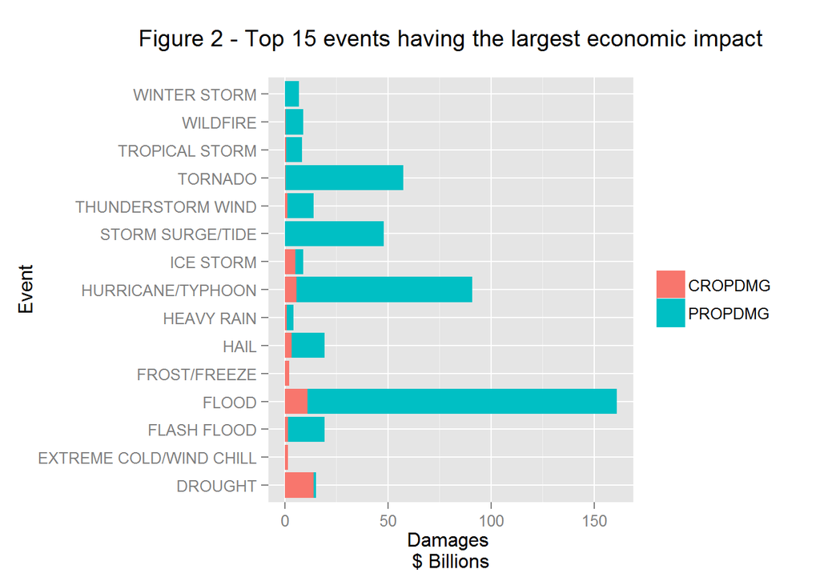

```r
#build the dataframe to be used for the graphical plot comparison
damages <- rbind (Top10_propdmg,Top10_cropdmg)

#add in the missing values for the property & crop damages as each DF had a different top 10 and we should include for completeness

damages <- rbind(damages,c("DROUGHT",propdmg[grep("DROUGHT",propdmg$EVTYPE),]$PROPAMT,"PROPDMG"))
damages <- rbind(damages,c("EXTREME COLD/WIND CHILL",propdmg[grep("EXTREME COLD/WIND CHILL",propdmg$EVTYPE),]$PROPAMT,"PROPDMG"))
damages <- rbind(damages,c("FROST/FREEZE",propdmg[grep("FROST/FREEZE",propdmg$EVTYPE),]$PROPAMT,"PROPDMG"))
damages <- rbind(damages,c("HEAVY RAIN",propdmg[grep("HEAVY RAIN",propdmg$EVTYPE),]$PROPAMT,"PROPDMG"))
damages <- rbind(damages,c("ICE STORM",propdmg[grep("ICE STORM",propdmg$EVTYPE),]$PROPAMT,"PROPDMG"))
damages <- rbind(damages,c("STORM SURGE/TIDE",cropdmg[grep("STORM SURGE/TIDE",cropdmg$EVTYPE),]$CROPAMT,"CROPDMG"))
damages <- rbind(damages,c("TORNADO",cropdmg[grep("TORNADO",cropdmg$EVTYPE),]$CROPAMT,"CROPDMG"))
damages <- rbind(damages,c("TROPICAL STORM",cropdmg[grep("TROPICAL STORM",cropdmg$EVTYPE),]$CROPAMT,"CROPDMG"))
damages <- rbind(damages,c("WILDFIRE",cropdmg[grep("WILDFIRE",cropdmg$EVTYPE),]$CROPAMT,"CROPDMG"))
damages <- rbind(damages,c("WINTER STORM",cropdmg[grep("WINTER STORM",cropdmg$EVTYPE),]$CROPAMT,"CROPDMG"))
damages$Damages <- as.numeric (damages$Damages)
# fix r-quirk to make sure fatalities are always the leftmost bar
damages <- arrange(damages,damages$Type)


#
# Plot the events that were harmful to the population
#
#create a line plot to show trend
g<- ggplot (damages, aes(x=Event, y=Damages, fill=factor(Type)))
g + geom_bar(position="stack",stat="identity")+
        labs(title="Figure 2 - Top 15 events having the largest economic impact\n",fill="",
        y="Damages \n$ Billions")+
        coord_flip ()
```